# Deterministic functions

PCB 6455 / BSC 4933: Biometry | Lecture 9

Dr. Brian Maitner

## Today’s agenda

- What a function is, and why you would write your own
- Finding a curve with the right shape for real data
- What the parameters do
- Fitting it by eye

Type and run on a code block: type it into your script and run it. You will need it later.

Code without the label is there to watch.

## Where we are

**Chapter 2:** *describe* the pattern. Histograms, boxplots, scatterplots.

**Chapter 3:** *name* the pattern. Write down a function that has that shape.

**Chapter 4 onward:** fit it, and ask whether you believe it.

## You have been using functions all semester

```r
read.csv()      mean()      hist()
plot()          filter()    summarise()
ggplot()        log10()     install.packages()
```

Every one works the same way:

**inputs go in, something happens, a result comes back.**

## Anatomy of a function call

```r
mean(c(2, 4, NA))
```

```
[1] NA
```

```r
mean(c(2, 4, NA), na.rm = TRUE)
```

```
[1] 3
```

- `mean` is the **name**
- `c(2, 4, NA)` and `na.rm = TRUE` are the **arguments**
- `na.rm` has a **default**, `FALSE`, used unless you say otherwise

## Functions are just code someone wrote

Type a function’s name without the brackets:

```r
sd
```

```
function (x, na.rm = FALSE)
sqrt(var(if (is.vector(x) || is.factor(x)) x else as.double(x),
    na.rm = na.rm))
<bytecode: 0x00000211e30bb540>
<environment: namespace:stats>
```

`sd()` is `sqrt()` of `var()`, with a default for `na.rm`.

You can write these too.

## Why write your own?

- **Stop copying and pasting.** Lecture 6’s four near-identical blocks: write it once instead.
- **Fix mistakes in one place.** One copy means one fix.
- **Give an idea a name.** `standard_error(x)` says what it does.
- **An equation is a function.** $f(x)$ in math, `function(x)` in R. That is this chapter.

## Writing your own

```r
standard_error <- function(x){
  sd(x) / sqrt(length(x))
}

standard_error(c(2, 4, 6, 8))
```

```
[1] 1.290994
```

- `standard_error` is the name you choose
- `function(x)` says what arguments it takes
- the body in `{ }` does the work; the last line is the result
- `x` is a **placeholder**: whatever you pass in becomes `x`

## Your turn

To convert Celsius to Fahrenheit: $F = \dfrac{9}{5}\,C + 32$

```r
# Here is the other direction:
f_to_c <- function(temp_f){
  (temp_f - 32) * 5 / 9
}

f_to_c(98.6)

# Write this one, from the math above:
c_to_f <- function(temp_c){

}

c_to_f(c(0, 37, 100))     # should give 32, 98.6, 212
```

## Now let’s use them

You can write a function.

So far, functions that convert one number into another.

Next: functions that **describe a pattern in data**.

## The question

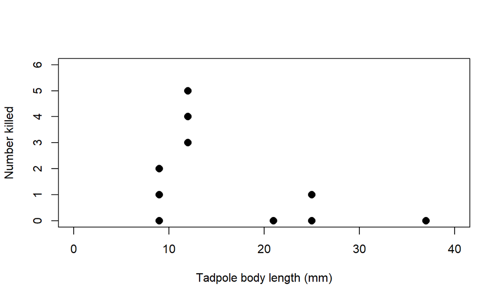

**What curve would you draw through this?**

## What shape do we need?

Load the data and plot it yourself:

```r
library(emdbook)
data(ReedfrogSizepred)
tadpoles <- ReedfrogSizepred
plot(tadpoles$TBL, tadpoles$Kill)
```

Reading it off the plot:

- It **rises** from the smallest tadpoles to about 12 mm
- It **peaks** around 12 mm
- It **falls back** toward zero for the biggest tadpoles

We need a function that can do all three.

## Two kinds of description

**Phenomenological:** a curve that fits. Chosen because it has the right shape.

**Mechanistic:** a curve derived from a theory about the process. Parameters mean something.

The same equation can be either, depending on why you chose it.

## First try: a curve you already know

The Holling type II from Lecture 2 **rises from zero**.

That is the first item on our list. Could it work?

## One curve, two ways to write it

**Mechanistic**  
Holling type II functional response

$$f(x) = \frac{\alpha\,x}{1 + \alpha\,h\,x}$$

- $x$: prey density
- $\alpha$: attack rate
- $h$: handling time

Written down from a theory of how predators forage.

**Phenomenological**  
Michaelis-Menten form

$$f(x) = \frac{a\,x}{b + x}$$

- $x$: prey density
- $a$: asymptote, the maximum
- $b$: half-saturation, where $f(x) = a/2$

Written down because it has the right shape.

**The same curve**, when $a = \dfrac{1}{h}$ and $b = \dfrac{1}{\alpha\,h}$.

## Same curve in R

You wrote the second one in Lecture 2, as `holling2()`.

```r
holling_type2 <- function(x, alpha, h){
  alpha * x / (1 + alpha * h * x)
}

michaelis_menten <- function(x, a, b){
  a * x / (b + x)
}

holling_type2(x = c(1, 5, 50), alpha = 2, h = 0.5)
```

```
[1] 1.000000 1.666667 1.960784
```

```r
michaelis_menten(x = c(1, 5, 50), a = 1 / 0.5, b = 1 / (2 * 0.5))
```

```
[1] 1.000000 1.666667 1.960784
```

Identical numbers. **Which one you write depends on why you are using it.**

## Math to R

| Math | R |  |
| --- | --- | --- |
| $a\,x$ | `a * x` | every multiplication needs `*` |
| $\dfrac{a}{b}$ | `a / b` |  |
| $x^2$ | `x^2` |  |
| $e^{-b x}$ | `exp(-b * x)` | a function, not a letter |
| $e$ | `exp(1)` | there is no `e` in R |
| $\ln(2)$ | `log(2)` | **`log()` is the natural log** |
| $\log_{10}(x)$ | `log10(x)` |  |
| $\sum_i y_i$ | `sum(y)` |  |

## Defaults

```r
michaelis_menten <- function(x, a = 1, b = 1){
  a * x / (b + x)
}
```

`a = 1` sets a **default**. Anything you leave out uses it.

```r
michaelis_menten(x = 2)
```

```
[1] 0.6666667
```

```r
michaelis_menten(x = 2, a = 3)
```

```
[1] 2
```

## Drawing it

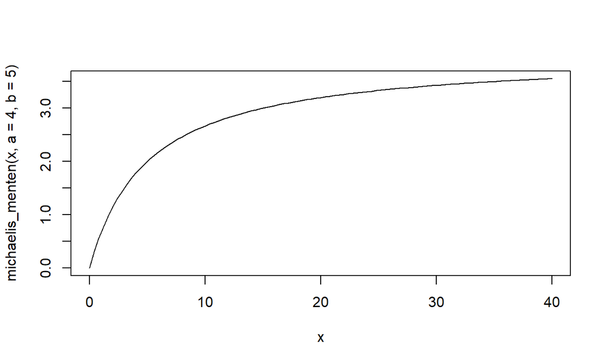

```r
curve(michaelis_menten(x, a = 4, b = 5), from = 0, to = 40)
```

## Try it against the data

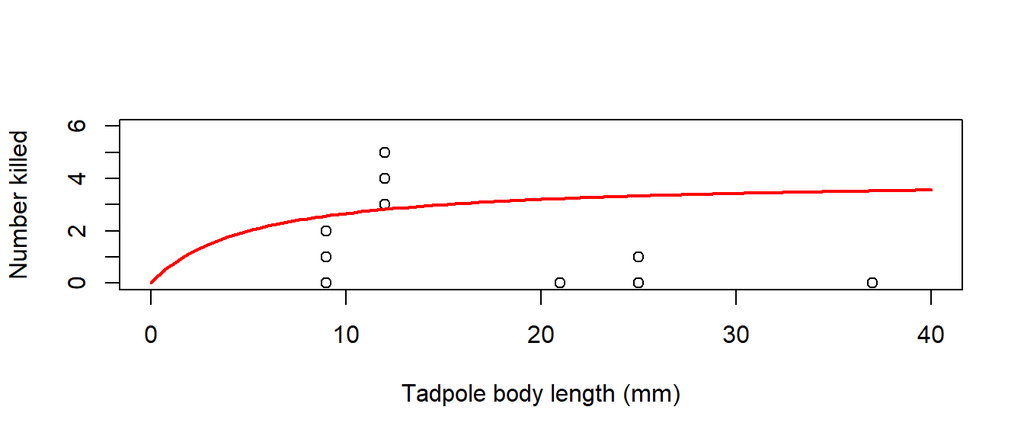

```r
plot(tadpoles$TBL, tadpoles$Kill, xlim = c(0, 40), ylim = c(0, 6),
     xlab = "Tadpole body length (mm)", ylab = "Number killed")
curve(michaelis_menten(x, a = 4, b = 5), add = TRUE, col = "red", lwd = 2)
```

Rises: **yes**. Peaks and falls back: **no**. It levels off and stays there.

## Second try: something that falls

Large tadpoles escape, so predation should **fall** with size.

The simplest curve that falls: the **negative exponential**.

## Your turn

The negative exponential: $f(x) = a\,e^{-b x}$. Write it in R.

```r
# You typed this one in earlier:
michaelis_menten <- function(x, a = 1, b = 1){
  a * x / (b + x)
}

# Make this one, from the math above:
negexp <- function(x, a = 1, b = 1){

}

curve(negexp(x), from = 0, to = 7)

# Compare the two shapes: put the Michaelis-Menten curve on top
curve(michaelis_menten(x, a = 2, b = 1), add = TRUE, col = "red")
```

## The negative exponential, in math and in R

**Math**

$$f(x) = a\,e^{-b x}$$

- $x$: the input, e.g. time
- $a$: the value at $x = 0$
- $b$: the decay rate ($b > 0$)

**R**

```r
negexp <- function(x, a = 1, b = 1){
  a * exp(-b * x)
}
```

- $e^{-b x}$ becomes `exp(-b * x)`

## Your turn

The last slide says what `a` and `b` do. **Check it**, changing only the numbers.

```r
# Round 1: three values of a, same b
curve(negexp(x, a = 1, b = 1), from = 0, to = 7, ylim = c(0, 3))
curve(negexp(x, a = 1, b = 1), add = TRUE, col = "red")
curve(negexp(x, a = 1, b = 1), add = TRUE, col = "blue")

# Round 2: same a, three values of b
curve(negexp(x, a = 1, b = 1), from = 0, to = 7, ylim = c(0, 3))
curve(negexp(x, a = 1, b = 1), add = TRUE, col = "red")
curve(negexp(x, a = 1, b = 1), add = TRUE, col = "blue")
```

In your own words: what does `a` seem to control? What does `b` seem to control?

## What does `a` do?

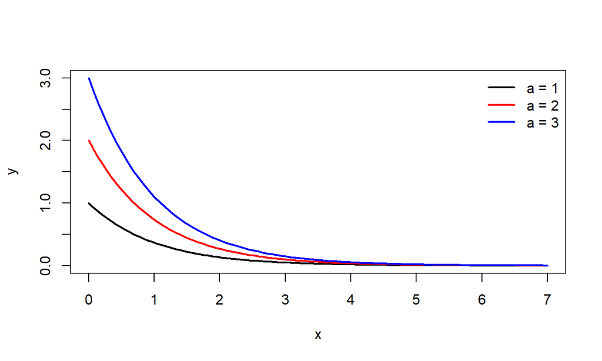

`a` is the value at x = 0.

## What does `b` do?

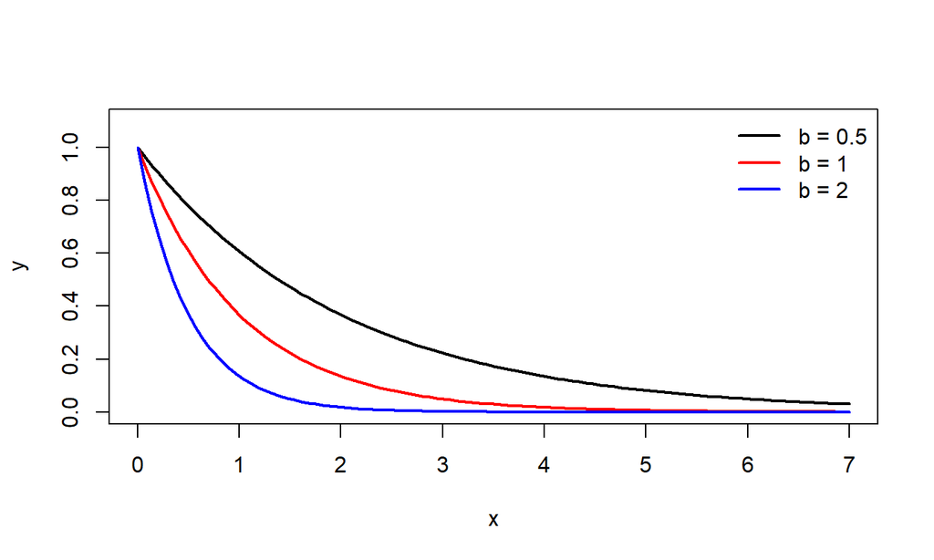

All start in the same place. `b` sets how fast it falls.

## Where does it fall by half?

For $f(x) = a\,e^{-b x}$ the book gives

$$x_{1/2} = \frac{\ln 2}{b}$$

In R, $\ln$ is `log()`. Check it:

```r
log(2) / 0.5
```

```
[1] 1.386294
```

```r
negexp(log(2) / 0.5, a = 1, b = 0.5)
```

```
[1] 0.5
```

This is a half-life. Bigger `b`, shorter half-life.

## Try it against the data

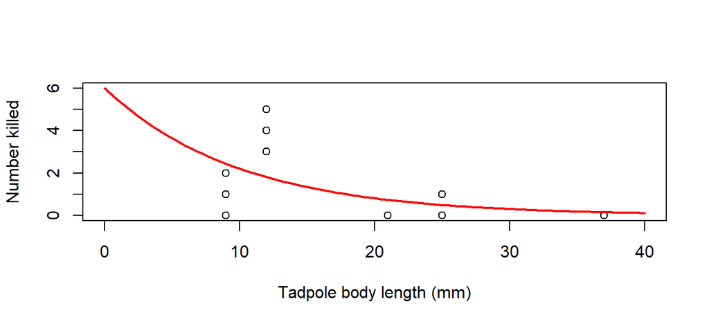

```r
plot(tadpoles$TBL, tadpoles$Kill, xlim = c(0, 40), ylim = c(0, 6),
     xlab = "Tadpole body length (mm)", ylab = "Number killed")
curve(negexp(x, a = 6, b = 0.1), add = TRUE, col = "red", lwd = 2)
```

Falls back: **yes**. Rises first: **no**. It starts at its highest point.

## Put them together

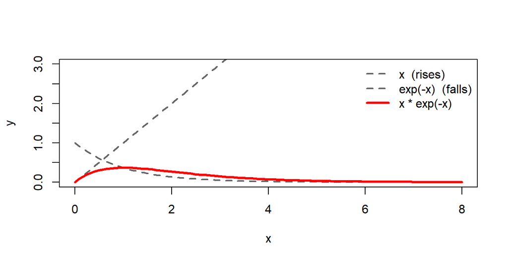

The Holling curve got the **rise**. The exponential got the **fall**. Multiply one that rises by one that falls: $x \times e^{-x}$ humps.

## The Ricker, in math and in R

That product, with a parameter on each piece, is the **Ricker**: the standard choice for humped, right-skewed ecological patterns.

**Math**

$$f(x) = a\,x\,e^{-b x}$$

- $x$: the input, e.g. tadpole size
- $a$: initial slope, how steeply it rises from zero
- $b$: sets where it peaks, at $x = 1/b$ ($b > 0$)

**R**

```r
ricker <- function(x, a = 1, b = 1){
  a * x * exp(-b * x)
}
```

- $a\,x$ is the rising piece
- $e^{-b x}$ is the falling piece

## Your turn: type in the Ricker

Type this into your script and run it. You will use it for the rest of today.

```r
ricker <- function(x, a = 1, b = 1){
  a * x * exp(-b * x)
}

ricker(x = 2)          # should give 0.2706706
```

Getting `could not find function "ricker"`? The definition has not been run yet.

## What happens at the ends?

You can just ask.

```r
ricker(0, a = 1, b = 1)
```

```
[1] 0
```

```r
ricker(c(10, 100, 1000), a = 1, b = 1)
```

```
[1] 4.539993e-04 3.720076e-42 0.000000e+00
```

Starts at zero. Returns to zero. With a hump in between, that is every item on our list.

Is starting at zero sensible for tadpoles?

## When you want the numbers

```r
xvec <- seq(from = 0, to = 8, length.out = 100)
yvec <- ricker(xvec, a = 1, b = 1)
head(yvec)
```

```
[1] 0.00000000 0.07453501 0.13749781 0.19023593 0.23395739 0.26974430
```

That worked because the function is **vectorized**.

If it is not, `sapply()` runs it one at a time:

```r
yvec <- sapply(X = xvec, FUN = ricker)
```

## Where is the peak?

```r
xvec <- seq(0, 20, length.out = 10000)
yvec <- ricker(xvec, a = 1, b = 0.25)
xvec[which.max(yvec)]
```

```
[1] 4.0004
```

The book does the calculus and gets $x_{\text{peak}} = \dfrac{1}{b}$.

```r
1 / 0.25
```

```
[1] 4
```

## The peak depends only on `b`

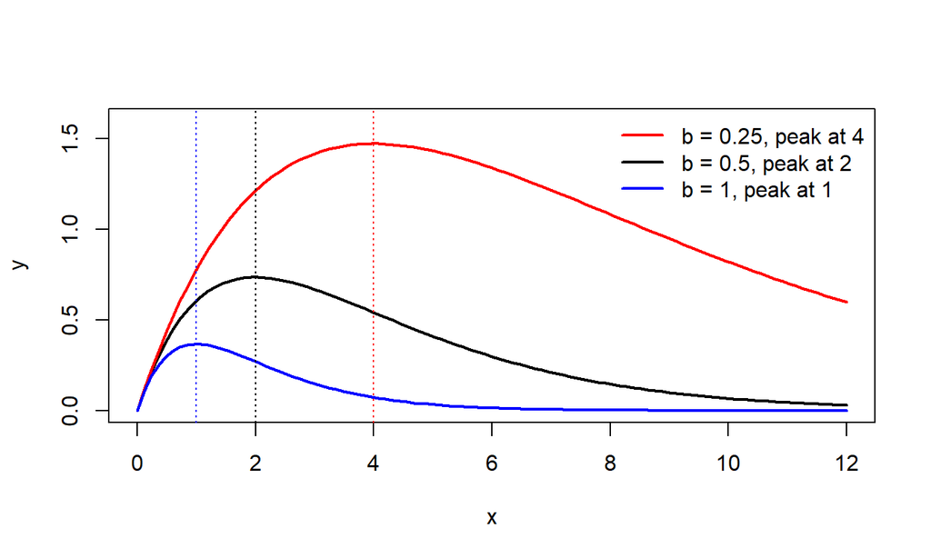

Changing `a` stretches it vertically. The peak stays put.

## Your turn

```r
# uses the ricker() you typed in earlier
a_try <- 1
b_try <- 0.1

curve(ricker(x, a = a_try, b = b_try), from = 0, to = 40)

# Find the peak numerically
xvec <- seq(0, 40, length.out = 10000)
yvec <- ricker(xvec, a = a_try, b = b_try)

xvec[which.max(yvec)]

1 / b_try            # does this agree?
```

Now set `a_try <- 5`. Did the peak move?

What `b_try` puts the peak at **x = 20**?

## Back to the tadpoles

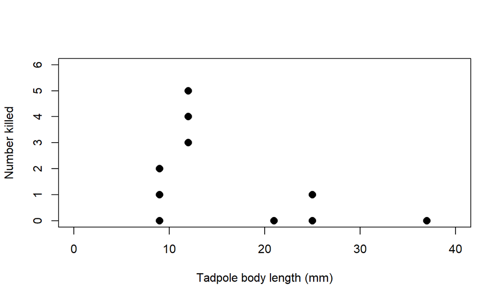

Peak near **12 mm**. Height about **4** killed.

That is two facts. The Ricker has two parameters.

## Eyeballing it

Peak is at `1/b`, and we want it at 12:

```r
b_eye <- 1 / 12
```

Height at the peak is $\dfrac{a}{b\,e}$, and we want 4. In R, $e$ is `exp(1)`:

```r
a_eye <- 4 * b_eye * exp(1)
a_eye
```

```
[1] 0.9060939
```

## How good is a fit?

$$\text{SS} = \sum_i \big(y_i - f(x_i)\big)^2$$

- $y_i$: each observed value, `tadpoles$Kill`
- $f(x_i)$: what the curve predicts there, `ricker(tadpoles$TBL, a, b)`
- $\sum_i$: add them all up, `sum()`

```r
sum((tadpoles$Kill - ricker(tadpoles$TBL, a = a_eye, b = b_eye))^2)
```

```
[1] 87.50341
```

Smaller is better.

## Your turn

```r
# uses the ricker() you typed in earlier
library(emdbook)
data(ReedfrogSizepred)
tadpoles <- ReedfrogSizepred

a_try <- 0.906                 # change these two
b_try <- 0.0833

plot(tadpoles$TBL, tadpoles$Kill, xlim = c(0, 40), ylim = c(0, 6))

curve(ricker(x, a = a_try, b = b_try), add = TRUE, col = "red", lwd = 2)

sum((tadpoles$Kill - ricker(tadpoles$TBL, a_try, b_try))^2)
```

Starting score: **87.5**. Lower is better. Can you beat it?

## It does not fit. Good.

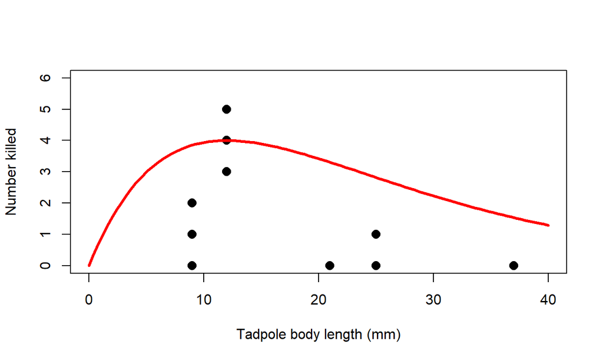

Right kind of shape, but the right tail is too heavy. So you modify the function.

## Before next class

Read Bolker **3.4 to 3.5**

Next time: the bestiary of functions, and modifying them to fit

Also: complete **3.6** (the R supplement)